# Coursera Milestone

Yupeng Lin

July 25, 2015

### Introduction

The coursera capstone project aims to build a predictive model for user input. The training set comes from three corpus extracted from blog, news and twitter. The prediction is based on word level instead of character level. Therefore, the n-gram algorithm is a used tool to build this model.

### Data Import

First of all, we can load the separate files via connection function.The length of those three corpus.

```r
filePath_blog <- "final/en_US/en_US.blogs.txt"
filePath_news <- "final/en_US/en_US.news.txt"
filePath_twitter <- "final/en_US/en_US.twitter.txt"
conn_blog <- file(filePath_blog)
conn_news <- file(filePath_news)
conn_twitter <- file(filePath_twitter)

set.seed(1234)

blogs <- readLines(conn_blog)
news <- readLines(conn_news)
twitter <- readLines(conn_twitter)

length(blogs)
```

```
## [1] 899288
```

```r
length(news)
```

```
## [1] 1010242
```

```r
length(twitter)
```

```
## [1] 2360148
```

### Sample the training set

From the length displayed above,we can see that it is a very large text file. however, in the english, most frequent words for daily use are around 50’000. Therefore, we can confidently drop a lot of corpus. This samll portion also helps us to facilitate the next step of data statistics.

```r
blog_index <- c(1:length(blogs))
blog_training_index <- sample(blog_index, round(length(blog_index) * 0.01))
blog_training_set <- blogs[blog_training_index]
blog_testing_set <- blogs[-blog_training_index]

news_index <- c(1:length(news))
news_training_index <- sample(news_index, round(length(news_index) * 0.01))
news_training_set <- news[news_training_index]
news_testing_set <- news[-news_training_index]

twitter <- readLines(conn_twitter)
twitter_index <- c(1:length(twitter))
twitter_training_index <- sample(twitter_index, round(length(twitter_index) * 0.01))
twitter_training_set <- twitter[twitter_training_index]
twitter_testing_set <- twitter[-twitter_training_index]

close(conn_blog)
close(conn_twitter)
close(conn_news)
training_set <- c(blog_training_set, news_training_set, twitter_training_set)
```

After we have the training set, we can close the file connection and concatnate those text into one very large character vector.

### Make Clean Data Set

Since the data sets came from various source, sentences and words in the corpus will generate a lot of useless information. The text mining package will help us to eliminate the punction, numbers, and convert all the word to lower case. In addition, the english stop word will also be eliminated for the efficiency of word.

```r
library(tm)
library(wordcloud)

training_set <- blogs[1:10000]
blog_corpus <- VCorpus(VectorSource(training_set))
toSpace <- content_transformer(function(x, pattern) gsub(pattern, " ", x))
blog_corpus <- tm_map(blog_corpus, toSpace, "/")
blog_corpus <- tm_map(blog_corpus, toSpace, "@")
blog_corpus<- tm_map(blog_corpus, toSpace, "\\|")
blog_corpus <- tm_map(blog_corpus,content_transformer(tolower))
blog_corpus <- tm_map(blog_corpus,removeNumbers)
blog_corpus <- tm_map(blog_corpus,removePunctuation)
blog_corpus <- tm_map(blog_corpus,removeWords, stopwords("english"))
blog_corpus <- tm_map(blog_corpus, stripWhitespace)
```

This result of word cleaning is displayed as following.

```r
as.character(blog_corpus[[4]])
```

```
## [1] " anyways going share home decor inspiration storing folder puter amazing images stored away ready come life get home"
```

### Unigram, bigram and trigram

We can move paste function to generate the unigram, bigram and trigram.

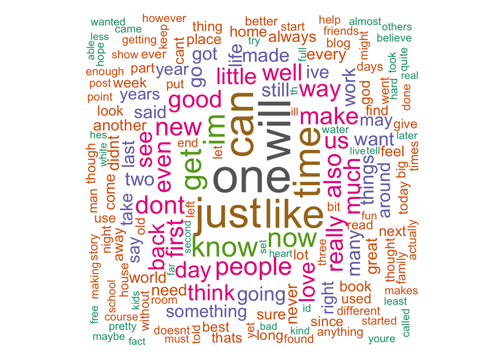

```r
sentence <- ""
for (i in 1:length(training_set)){
  sentence <- paste(sentence, as.character(blog_corpus[[i]]))
}
tokens <- unlist(strsplit(sentence," "))
tokens <- tokens[tokens != ""]

two_tokens <- c("")
three_tokens <-c("")

for(i in 1:length(training_set)){
  sentence <- ""
  sentence <- paste(sentence, as.character(blog_corpus[[i]])) #ingest single sentence
  one_token <- unlist(strsplit(sentence," "))
  one_token <- one_token[one_token != ""]
  one_token_moved <- c(one_token[-1], ".")
  sentence_tokens <- paste(one_token, one_token_moved)
  two_tokens <- c(two_tokens, sentence_tokens)

  one_token_moved2 <- c(one_token_moved[-1], ".")
  trigram_tokens <- paste(one_token, one_token_moved, one_token_moved2)
  three_tokens <- c(three_tokens, trigram_tokens)
}
load("token_one_percent.RData")

freq_one <- sort(table(tokens), decreasing=T)
stat_one <- data.frame(word = row.names(freq_one), count = as.vector(freq_one))
stat_one$prob <- stat_one$count / length(tokens)

freq_two <- sort(table(two_tokens), decreasing = T)
stat_two <- data.frame(word = row.names(freq_two), count = as.vector(freq_two))
stat_two$prob <- stat_two$count / length(two_tokens)

freq_three <- sort(table(three_tokens), decreasing = T)
stat_three <- data.frame(word= row.names(freq_three), count = as.vector(freq_three))
stat_three$prob <- stat_three$count / length(three_tokens)

wordcloud(words = stat_one$word, freq = stat_one$count, min.freq = 1,
         max.words=200, random.order=FALSE, rot.per=0.35,
         colors=brewer.pal(8, "Dark2"))
```

```r
head(stat_one)
```

```
##   word count        prob
## 1  one  1327 0.006207403
## 2 will  1233 0.005767693
## 3 just  1158 0.005416860
## 4  can  1137 0.005318626
## 5 like  1091 0.005103449
## 6 time  1016 0.004752616
```

```r
head(stat_two, 10)
```

```
##         word count         prob
## 1     said .   435 0.0008500493
## 2      lol .   335 0.0006546357
## 3      day .   277 0.0005412958
## 4      now .   254 0.0004963507
## 5  right now   228 0.0004455431
## 6     time .   217 0.0004240476
## 7    today .   192 0.0003751942
## 8  cant wait   187 0.0003654235
## 9  dont know   180 0.0003517446
## 10    year .   172 0.0003361115
```

Notice: the period means the end of sentence.

### Algorithm

Next word can be predicted by calculated probability given previous word. For example, give “of” we can use bigram table to find out which word has highest frequecy following the word “of”.

Improved algorithm – back-off algorithm

N-gram preforms very well given the previous word in the n-gram table. What if the previous word does not exist in the n-gram table. There is a solution:

P(Wi | Wi-1, Wi-2) = 0.6P(Wi | Wi-1, Wi-2) + 0.3P(Wi | Wi-1) + 0.1P(Wi)

By this way, we can successfuly predict the word that does not show up previously.